# A Bayesian Study of PM2.5 Data in Shanghai

Final Project of Bayesian Statistics

Bingying Xia

June 23, 2017

# Abstract

In this project, we explore the density function of $PM2.5$ data in Shanghai using Bayesian Method. The original data , from Dec, 2013 to Jun, 2017, ranges from $18.9$ to $125 \mu g/m^{3}$, with an average at $50.73 \mu gm^{3}$. We assume that $PM2.5$ is log-normally distributed $Lognormal(\mu, \sigma^{2})$. We use four different prior to find the posterior estimators $\mu$ and $\sigma^{2}$. That’s (1)Flat prior, (2)Weakly informative conjugate prior, (3)Informative Conjugate Prior and (4)Informative Conjugate Prior with one more Hierachical Stage. Our model is not sensitive to the prior. Since the model with flat prior has the least DIC, we find the posterior distribution of $PM2.5$ is $Lognormal(3.869,0.1116)$. The posterior mean of $PM2.5$ is $ 50.67 g/m^{3}$. According to the [“Ambient Air Quality Standards”](http://english.mep.gov.cn/Resources/standards/Air_Environment/quality_standard1/201605/W020160511506615956495.pdf), the $PM2.5$ concentration in Shanghai is above the second level, but still below the annual average, around 61$\mu g/m^{3}$, all over the country.

# Data description

We find this data from [“Air Quality-Shanghai”](https://www.aqistudy.cn/historydata/monthdata.php?city=上海) . The data record the air quality information in Shanghai from Dec, 2013 to Jun, 2017. There are 43 entries, including variables Month, AQI(Air Quality Index), $PM2.5$, $PM10$, $SO_{2}$, $CO$, $NO_{2}$ and $O_{3}$. However, we just want to study the distribution of $PM2.5$.

```r
#load data
setwd("C:/Users/ivy_x/Documents/贝叶斯/proj")
mydata=read.csv("shanghai-airplt-longtime.csv",sep=",",header = T)
head(mydata)
```

```
##     月份 AQI PM2.5  PM10  SO2    CO  NO2    O3
## 1 13-Dec 158 125.0 139.7 48.1 1.373 71.1  48.9
## 2 14-Jan 103  76.6  90.0 28.0 0.997 53.7  58.2
## 3 14-Feb  74  52.3  58.6 16.6 0.796 36.2  72.5
## 4 14-Mar  82  56.9  84.2 19.3 0.787 51.0  99.6
## 5 14-Apr  77  52.9  67.4 15.3 0.727 46.7 108.0
## 6 14-May  96  62.8  99.3 17.4 0.777 42.4 142.1
```

```r
y=mydata$PM2.5
summary(y)
```

```
##    Min. 1st Qu.  Median    Mean 3rd Qu.    Max.
##   18.90   39.70   47.40   50.73   56.35  125.00
```

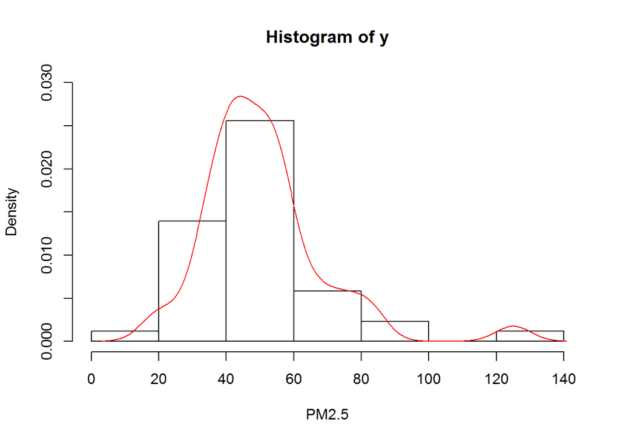

```r
hist(y,xlab = "PM2.5",probability = T,ylim=c(0,0.03))
lines(density(y),col=2)
```

Since the data on concentration of PM2.5 are right skewed, the log transformation is used to symmetrize their distribution.

```r
y=log(mydata$PM2.5)
summary(y)
```

```
##    Min. 1st Qu.  Median    Mean 3rd Qu.    Max.
##   2.939   3.681   3.859   3.870   4.032   4.828
```

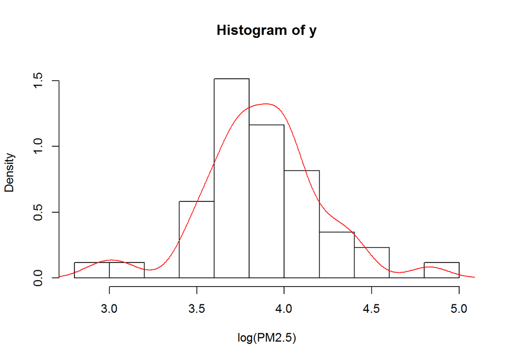

```r
hist(y,xlab = "log(PM2.5)",probability = T,ylim = c(0,1.6))
lines(density(y),col=2)
```

The histogram looks more bell-curved now.

# Methods used in the Data Analysis

Let $log(Y_{i})$ be the $log(PM2.5)$ value during the data. We assume that the data follow a $Lognormal$ distribution.

$$Y_{i} \mid \mu, \sigma^{2} \sim \text{Lognormal}(\mu, \sigma^{2})$$

Obiviously, that’s

$$log(Y_{i}) \mid \mu, \sigma^{2} \sim \text{Normal}(\mu, \sigma^{2})$$

Our objective is to estimate the joint distribution of $(\mu,\sigma^{2})$. We will select different priors, compare them and find out which one is the best one in this case.

There are 2 prior families we take into consideration: *Flat prior* Conjugate prior

## 1. Flat prior

$$log(Y_{i}) \mid \mu, \sigma^{2} \sim \text{Normal}(\mu, \sigma^{2})$$

$$\mu \sim U(-10^{4},10^{4})$$

$$\sigma^{2} \sim U(0,10^{4})$$

## 2. Conjugate Prior

### 1. Weakly informative prior

$$log(Y_{i}) \mid \mu, \sigma^{2} \sim \text{Normal}(\mu, \sigma^{2})$$

$$\mu \sim \text{Normal}(0,10^{-1})$$

$$\tau^{2}=1/\sigma^{2}$$

$$\tau^{2} \sim \text{Gamma}(10^{-1},10^{-1})$$

### 2. Informative Prior

$$log(Y_{i}) \mid \mu, \sigma^{2} \sim \text{Normal}(\mu, \sigma^{2})$$

$$\mu \sim \text{Normal}(\mu_{for\mu},\sigma^{2}_{for\mu})$$

$$\tau^{2} \sim Gamma(\alpha,\beta)$$

#### Specifying the Prior Parameters

To complete our informatiove Bayesian model, we need to choose numeric values for parameters $\mu_{for \mu}$ and $\tau_{for \mu}$, $\alpha_{for \sigma^{2}}$ and $\beta_{for \sigma^{2}}$. Recall that our data are log-transformed. We are **not** experts on **Environmental Research and Public Health**, but we do find some information.

From the [“Ambient Air Quality Standards”](http://english.mep.gov.cn/Resources/standards/Air_Environment/quality_standard1/201605/W020160511506615956495.pdf) released on February, 2012 and impemented on January, 2016, the standard $\rho(PM2.5)$ concentrations are showed below.

| PM2.5($\mu g /m^{3}$) | First Class | Second Class |
| --- | --- | --- |
| Annually Average | 15 | 35 |
| 24 Hour Average | 35 | 75 |

However, PM2.5 accounts for much of the frequent occurrence of extreme haze episodes in Shanghai in recent years. From [“a year long study”](https://www.researchgate.net/publication/310748192) utilizing 945 monitoring stations in 190 cities in China, the researchers found significant difference in concentration of PM2.5, ranging between 18.7 and 131.4 $\mu g/m^{3}$, with an annual average at $61\pm 20 \mu g/m^{3}$.

Then we assume that the mean of our prior should be around `log(61)`, that’s 4.111.

Now we need the prior precision, $\tau_{0}^{2}$. We had about as much blief in the mean 4.111 as if we had seen 3 previous observations. Thus, for the conjugate prior, $\mu_{for\mu}$ will be 4.111, and $\kappa$ will be 3.

We didn’t find any solid evidenve to show the variance of PM2.5. However, we believe the variance should be around 20.

Then we specified an inverse gamma prior with parameters $\alpha_{for\tau^{2}}=10$ and $\beta_{for\tau^{2}}=0.5$.

### 3. Informative Prior with one more Hierachical Stage

$$log(Y_{i}) \mid \mu, \sigma^{2} \sim \text{Normal}(\mu, \sigma^{2})$$

$$\mu \sim \text{Normal}(\mu_{for\mu},\sigma^{2}_{for\mu})$$

$$\tau^{2} \sim Gamma(\alpha,\beta)$$

$$\alpha=20\times \beta$$

$$\beta \sim U(0,50)$$

Since we just assume that the variance of $y$ is around $20$, we are not sure about the distribution of $\sigma^{2}$. Thus, we set $\beta$ to be a random variable as well, and assume $\alpha = 20\times \beta$ so that the mean of $Gamma(\alpha, \beta)$ will be $20$.

# Data Analysis

## 1. Flat Prior

**Click Here to read output.**

The output explains that three chains were used, each with $10000$ iteration, and the first $5000$ iterations(the burn-in) were discarded in each chain, so total $15000$ MCMC samples were saved to define the posterior distribution of each parameter. The table lists the summary statistics for each estimated parameter($N=15000$), including critical quantiles(the $2.5\%$ and $97.5\%$ stats represent a $95\%$ Bayesian credible interval, which states that there is a $95\%$ chance that the real parameter value lies within this range). The $95\%$ Bayesian credible interval for $\mu$ is $[3.8,4.0]$, and the $95\%$ CI for $\sigma^{2}$ is $[0.1,0.2]$.

The `Rhat` value is a measure of convergence that takes into account the different starting values for the different chains; this should be $1$ or close to it. `n.eff` is a sample size statistic that takes convergence criteria into account.

The Deviance Information Criterion is $32.1$.

The trace plots show the values the parameter took during the runtime of the chain. From the trace plots we can see the log($\mu$) is around $3.85 \sim 3.9$ and the $\sigma^{2}$ is less than $0.25$.

The density plot reveals similar information to the trace plots. We can see form the plot that $\mu$ is bell-curved. However, $\sigma^{2}$ is skewed to the right.

The autocorrelation plots shows that there is no strong autocorrelation between samples.

The gelman.diag gives us the scale reduction factors for each parameter. A factor $1$ means that between variance and within chain variance are equal, large values mean there is still a notable difference between chain. It’s clear that $\mu$ and $\sigma^{2}$ all have settled down before the last interval.

## 2. Weakly informative prior

**Click Here to read output.**

The diagnosis is almost the same as the one in **Flat Prior**, except for the fact that the DIC increases to $32.3$.

## 3. Informative Prior

**Click Here to read output.**

The diagnosis is almost the same as the one in **Weak Informative Prior**, even for the DIC.

## 4. Informative Prior with one more Hierachical Stage

**Click Here to read output.**

# Main Results

| Different Model | DIC | $\mu$ | $\sigma^{2}$ |
| --- | --- | --- | --- |
| Flat Prior | 32.1 | 3.869 | 0.115 |
| Weakly informative prior | 32.3 | 3.869 | 0.121 |
| Informative Prior | 32.3 | 3.871 | 0.094 |
| Informative Prior with one more Hierachical Stage | 34.5 | 3.872 | 0.092 |

From the table above we know model with flat prior has the least DIC. The model is not sensitive to the prior. Then we construct scatterplots of the simulated draws from the posterior distribution of $(\mu,\sigma^{2})$. Since the $\sigma^{2}$ data is somewhat skewed, we take the median as the estimator.

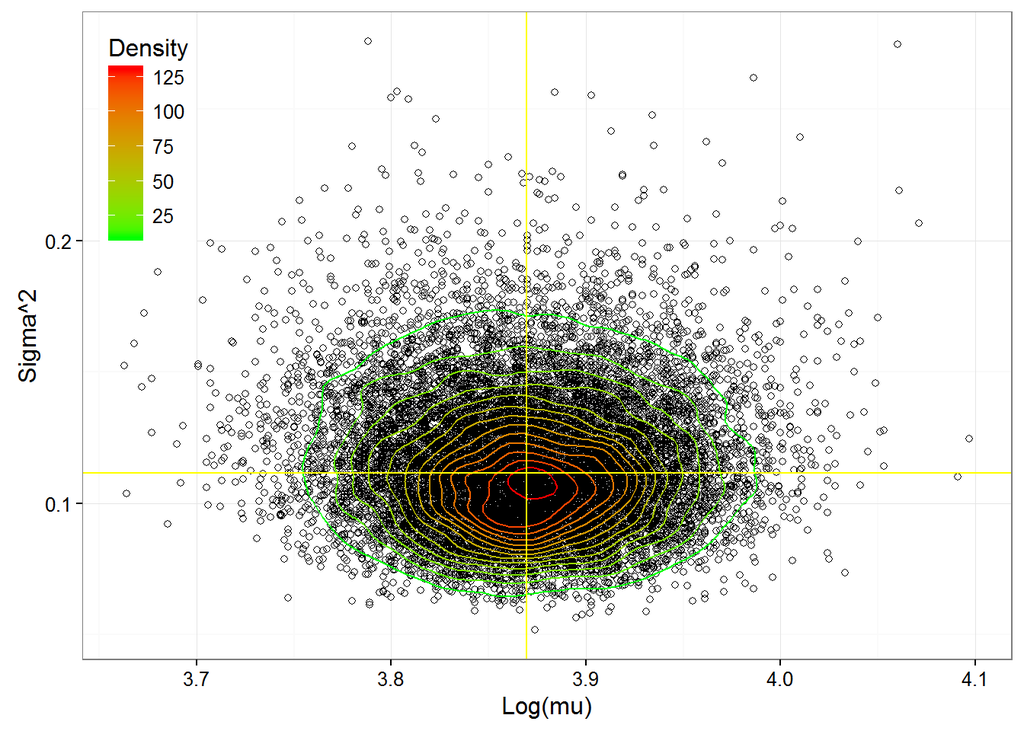

```r
library(ggplot2)
attach.bugs(out.flat)
df=data.frame(cbind(mu,s2))
colnames(df)=c("x","y")

commomtheme=list(labs(color="Density",fill="Density",x="Log(mu)",y="Sigma^2"),theme_bw(),theme(legend.position=c(0,1),legend.justification=c(0,1)))

ggplot()+geom_point(data=df,aes(x,y),shape=1,colour="black")+geom_density2d(data=df,aes(x,y,color=..level..))+scale_color_gradient(low="green",high="red")+geom_vline(xintercept =out.flat$mean$mu,colour="yellow")+geom_hline(yintercept =out.flat$median$s2,colour="yellow")+commomtheme
```

```r
out.flat$mean$mu
```

```
## [1] 3.869682
```

```r
out.flat$median$s2
```

```
## [1] 0.1116
```

Recall that we use log transformation before. Thus we have to transform the $log(\mu)$ to $\mu$. The posterior mean of $PM2.5$ in Shanghai is 47.927, and the $95\%$ Bayesian confidence interval is 43.2933914, 53.0375419.

From mathematical statistics, we know if the random variable $X$ us log-normally distributed, then $Y=ln(X)$ has a normal distribution $N(\mu, \sigma^{2})$.

Then the arithmetic mean and arithmetic standard deviation of a log-normally distributed variable $X$ are given by

$$E[X]=e^{\mu+1/2\sigma^{2}}$$

$$Var[X]=e^{2\mu+\sigma^{2}}(e^{\sigma^{2}}-1)$$

That’s

```r
a=out.flat$mean$mu
b=out.flat$median$s2
exp(a+b/2)
```

```
## [1] 50.67752
```

```r
exp(2*a+b)*(exp(b)-1)
```

```
## [1] 303.2172
```

# Summary

Based on the analysis above, estimators about the distribution of $log(PM2.5)$ are obtained.

$$Log(PM2.5) \sim Normal(3.869, 0.1116)$$

Then we know

$$PM2.5 \sim Lognormal(3.869,0.1116)$$

From the plot below we know our posterior is kind of like the shape of our likelihood.

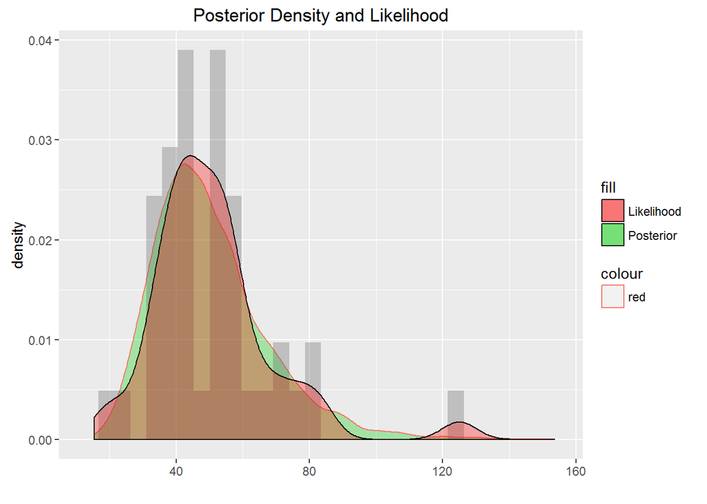

```r
m=matrix(rlnorm(5000,3.869,sqrt(0.112)),ncol = 1)
df=as.data.frame(m)
colnames(df)="PD"
df2=data.frame(mydata$PM2.5)
ggplot(df,aes(x=PD))+geom_density(aes(colour="red",fill="red"),alpha=0.3)+geom_histogram(data=df2,aes(mydata.PM2.5,y=..density..),alpha=0.3)+ggtitle("Posterior Density and Likelihood")+xlab("")+geom_density(data=df2,aes(x=mydata.PM2.5,y=..density..,fill="black"),alpha=0.3)+scale_fill_manual(values=c(2,3),labels=c("Likelihood","Posterior"))
```

# Reference

We failed to figure out how to add bibliography in markdown, so we just used inline links to make references.

- [“Air Quality-Shanghai”](https://www.aqistudy.cn/historydata/monthdata.php?city=上海)
- [“Ambient Air Quality Standards”](http://english.mep.gov.cn/Resources/standards/Air_Environment/quality_standard1/201605/W020160511506615956495.pdf)
- [“a year long study”](https://www.researchgate.net/publication/310748192)

# R Output

## 1. Flat Prior

Here is the R output for Flat Prior.

```r
library(R2OpenBUGS)
model.file=file.path("modelflat.txt")
n=dim(mydata)[1]
inits=function(){list(tau=runif(3,0,10000),mu=runif(3,-10000,10000))}
params=c("mu","s2")
data=list("n","y")
out.flat=bugs(data,inits,params,model.file,n.chains=3,n.iter = 10000,DIC = T)
#Diagnose
print(out.flat)
```

```
## Inference for Bugs model at "modelflat.txt",
## Current: 3 chains, each with 10000 iterations (first 5000 discarded)
## Cumulative: n.sims = 15000 iterations saved
##          mean  sd 2.5%  25%  50%  75% 97.5% Rhat n.eff
## mu        3.9 0.1  3.8  3.8  3.9  3.9   4.0    1 15000
## s2        0.1 0.0  0.1  0.1  0.1  0.1   0.2    1 15000
## deviance 30.1 2.0 28.2 28.7 29.5 30.9  35.7    1 11000
##
## For each parameter, n.eff is a crude measure of effective sample size,
## and Rhat is the potential scale reduction factor (at convergence, Rhat=1).
##
## DIC info (using the rule, pD = Dbar-Dhat)
## pD = 2.0 and DIC = 32.1
## DIC is an estimate of expected predictive error (lower deviance is better).
```

```r
#coda
out.flat.coda=bugs(data,inits,params,model.file,n.chains=3,n.iter = 10000,codaPkg = T)
library(lattice)
library(coda)
out.coda=read.bugs(out.flat.coda)
```

```
## Abstracting deviance ... 5000 valid values
## Abstracting mu ... 5000 valid values
## Abstracting s2 ... 5000 valid values
## Abstracting deviance ... 5000 valid values
## Abstracting mu ... 5000 valid values
## Abstracting s2 ... 5000 valid values
## Abstracting deviance ... 5000 valid values
## Abstracting mu ... 5000 valid values
## Abstracting s2 ... 5000 valid values
```

```r
summary(out.coda)
```

```
##
## Iterations = 5001:10000
## Thinning interval = 1
## Number of chains = 3
## Sample size per chain = 5000
##
## 1. Empirical mean and standard deviation for each variable,
##    plus standard error of the mean:
##
##             Mean      SD  Naive SE Time-series SE
## deviance 30.1268 2.02796 0.0165582      0.0169083
## mu        3.8697 0.05185 0.0004234      0.0004231
## s2        0.1151 0.02570 0.0002099      0.0002178
##
## 2. Quantiles for each variable:
##
##             2.5%     25%     50%     75%   97.5%
## deviance 28.1700 28.7100 29.5000 30.8800 35.6900
## mu        3.7680  3.8350  3.8690  3.9050  3.9710
## s2        0.0753  0.0969  0.1116  0.1294  0.1753
```

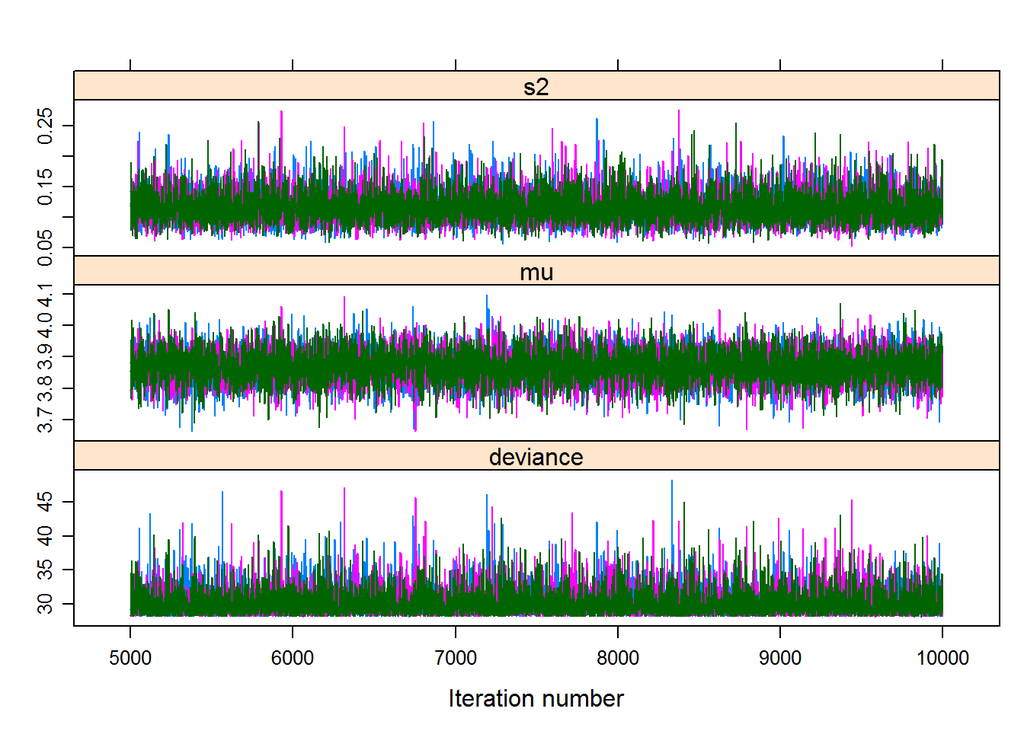

```r
xyplot(out.coda)
```

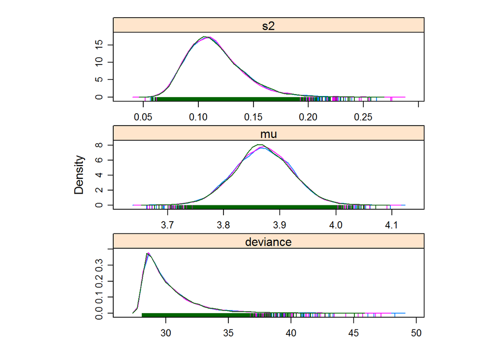

```r
densityplot(out.coda)
```

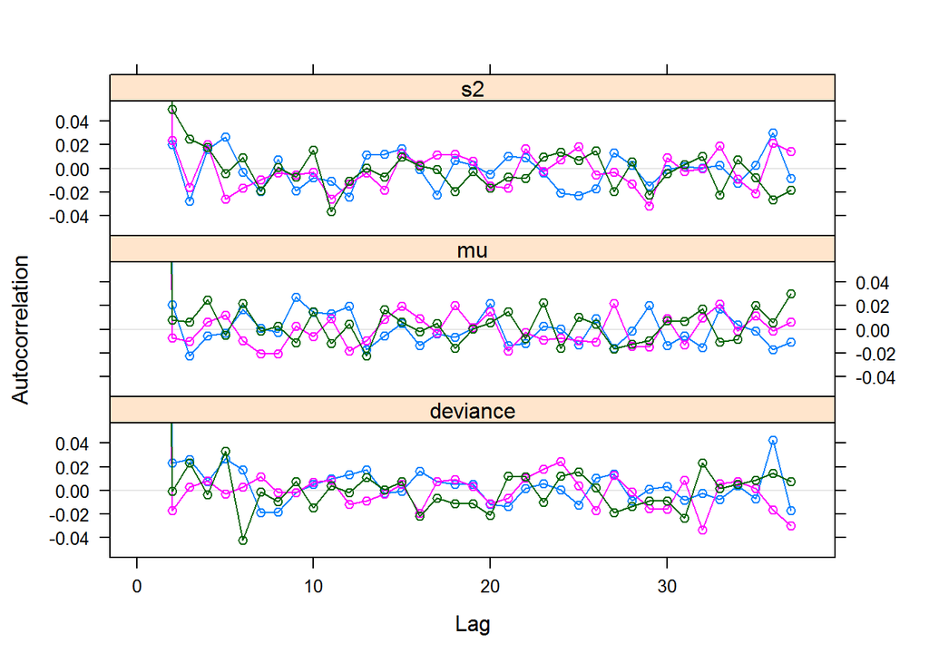

```r
acfplot(out.coda)
```

```r
gelman.diag(out.coda)
```

```
## Potential scale reduction factors:
##
##          Point est. Upper C.I.
## deviance          1          1
## mu                1          1
## s2                1          1
##
## Multivariate psrf
##
## 1
```

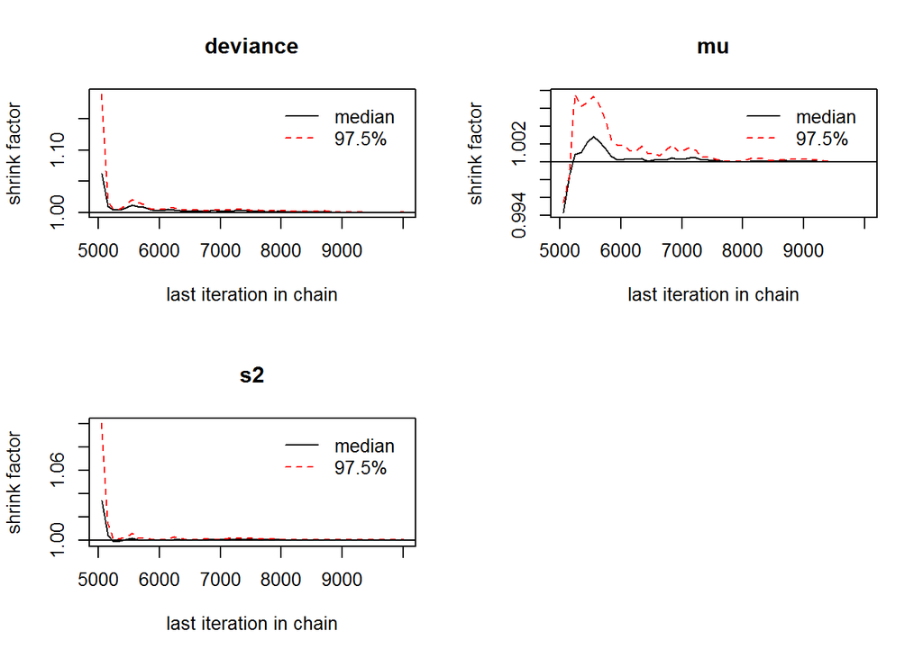

```r
gelman.plot(out.coda)
```

**Click Here to go back to analysis.**

## 2. Weakly informative prior

Here is the R output for Weakly informative prior.

```r
model.file=file.path("modelweak.txt")
inits.wk=function(){list(tau=rgamma(3,0.1,0.1),mu=rnorm(3,0,10))}
out.wk=bugs(data,inits.wk,params,model.file,n.chains=3,n.iter = 10000,DIC = T)
#Diagnose
print(out.wk)
```

```
## Inference for Bugs model at "modelweak.txt",
## Current: 3 chains, each with 10000 iterations (first 5000 discarded)
## Cumulative: n.sims = 15000 iterations saved
##          mean  sd 2.5%  25%  50%  75% 97.5% Rhat n.eff
## mu        3.9 0.1  3.8  3.8  3.9  3.9   4.0    1 15000
## s2        0.1 0.0  0.1  0.1  0.1  0.1   0.2    1 15000
## deviance 30.2 2.1 28.2 28.7 29.6 31.1  35.9    1 15000
##
## For each parameter, n.eff is a crude measure of effective sample size,
## and Rhat is the potential scale reduction factor (at convergence, Rhat=1).
##
## DIC info (using the rule, pD = Dbar-Dhat)
## pD = 2.0 and DIC = 32.3
## DIC is an estimate of expected predictive error (lower deviance is better).
```

```r
out.wk.coda=bugs(data,inits.wk,params,model.file,n.chains=3,n.iter = 10000,codaPkg = T)
out.coda=read.bugs(out.wk.coda)
```

```
## Abstracting deviance ... 5000 valid values
## Abstracting mu ... 5000 valid values
## Abstracting s2 ... 5000 valid values
## Abstracting deviance ... 5000 valid values
## Abstracting mu ... 5000 valid values
## Abstracting s2 ... 5000 valid values
## Abstracting deviance ... 5000 valid values
## Abstracting mu ... 5000 valid values
## Abstracting s2 ... 5000 valid values
```

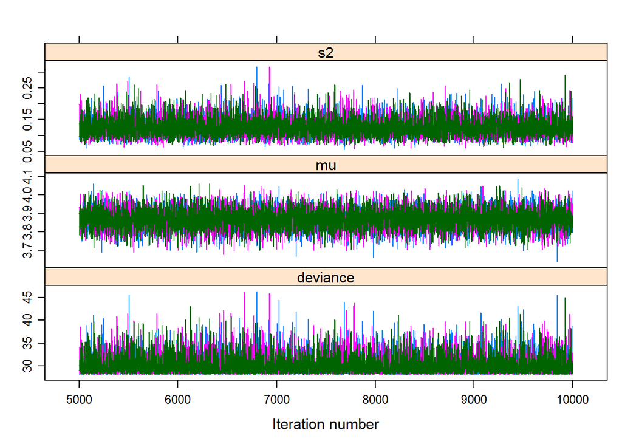

```r
xyplot(out.coda)
```

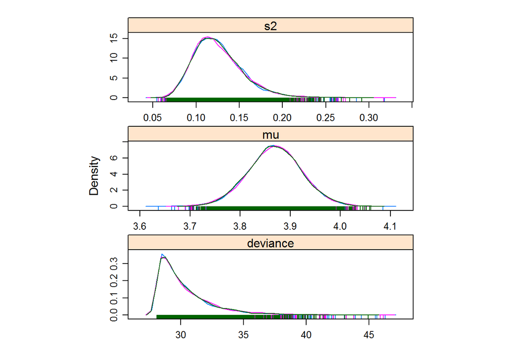

```r
densityplot(out.coda)
```

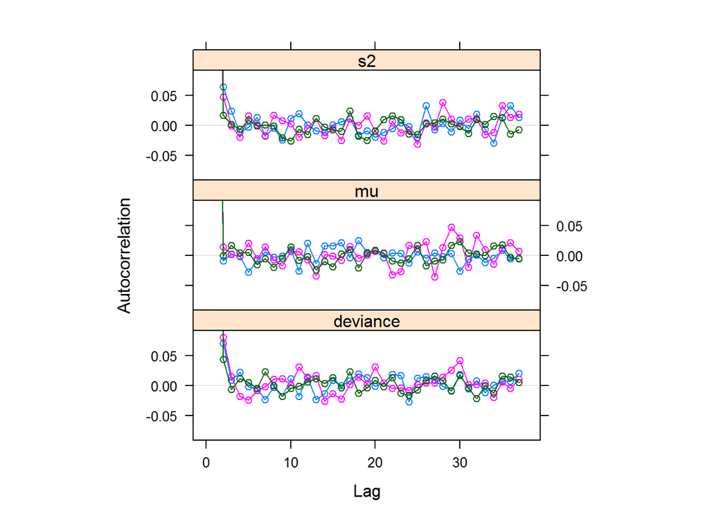

```r
acfplot(out.coda)
```

```r
gelman.diag(out.coda)
```

```
## Potential scale reduction factors:
##
##          Point est. Upper C.I.
## deviance          1          1
## mu                1          1
## s2                1          1
##
## Multivariate psrf
##
## 1
```

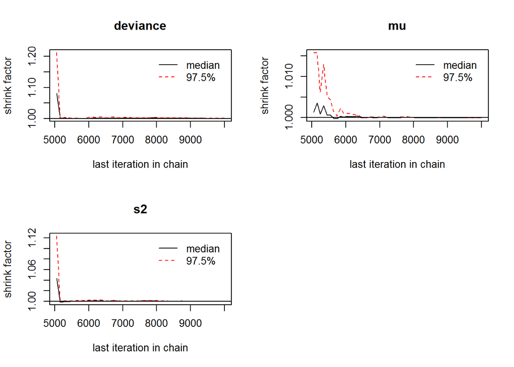

```r
gelman.plot(out.coda)
```

**Click Here to go back to analysis.**

## 3. Informative Prior

Here is the R output for Informative Prior.

```r
model.file=file.path("modelinf103.txt")
inits=function(){
  tau<-rgamma(3,10,0.5)
  s.mu<-1/sqrt(tau/3)
  mu<-rnorm(3,4.111,s.mu)
  list(tau,mu)
}
out.inf=bugs(data,inits,params,model.file,n.chains=3,n.iter = 10000)

print(out.inf)
```

```
## Inference for Bugs model at "modelinf103.txt",
## Current: 3 chains, each with 10000 iterations (first 5000 discarded)
## Cumulative: n.sims = 15000 iterations saved
##          mean  sd 2.5%  25%  50%  75% 97.5% Rhat n.eff
## mu        3.9 0.0  3.8  3.8  3.9  3.9   4.0    1  5000
## s2        0.1 0.0  0.1  0.1  0.1  0.1   0.1    1 15000
## deviance 30.6 2.4 28.2 28.9 30.0 31.6  37.0    1 15000
##
## For each parameter, n.eff is a crude measure of effective sample size,
## and Rhat is the potential scale reduction factor (at convergence, Rhat=1).
##
## DIC info (using the rule, pD = Dbar-Dhat)
## pD = 1.7 and DIC = 32.3
## DIC is an estimate of expected predictive error (lower deviance is better).
```

```r
out.inf.coda=bugs(data,inits,params,model.file,n.chains=3,n.iter = 10000,codaPkg = T)
out.coda=read.bugs(out.inf.coda)
```

```
## Abstracting deviance ... 5000 valid values
## Abstracting mu ... 5000 valid values
## Abstracting s2 ... 5000 valid values
## Abstracting deviance ... 5000 valid values
## Abstracting mu ... 5000 valid values
## Abstracting s2 ... 5000 valid values
## Abstracting deviance ... 5000 valid values
## Abstracting mu ... 5000 valid values
## Abstracting s2 ... 5000 valid values
```

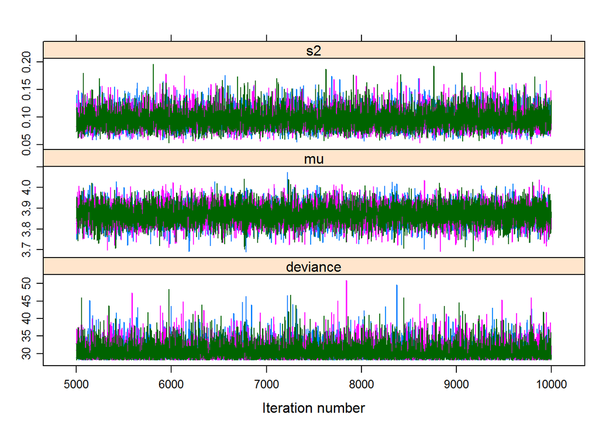

```r
xyplot(out.coda)
```

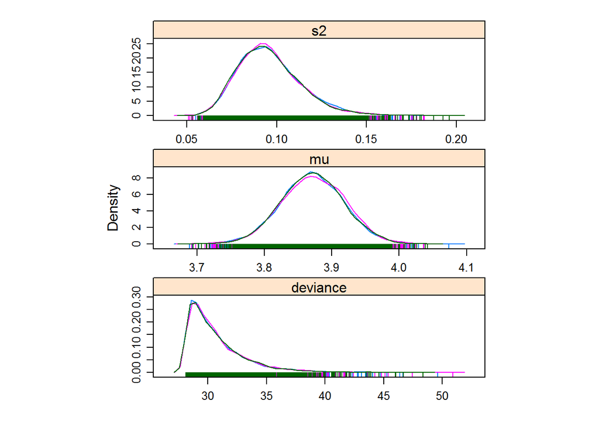

```r
densityplot(out.coda)
```

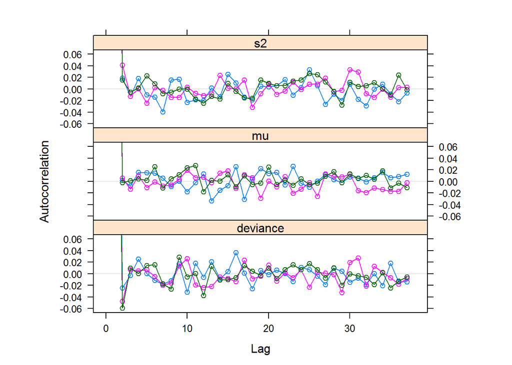

```r
acfplot(out.coda)
```

```r
gelman.diag(out.coda)
```

```
## Potential scale reduction factors:
##
##          Point est. Upper C.I.
## deviance          1          1
## mu                1          1
## s2                1          1
##
## Multivariate psrf
##
## 1
```

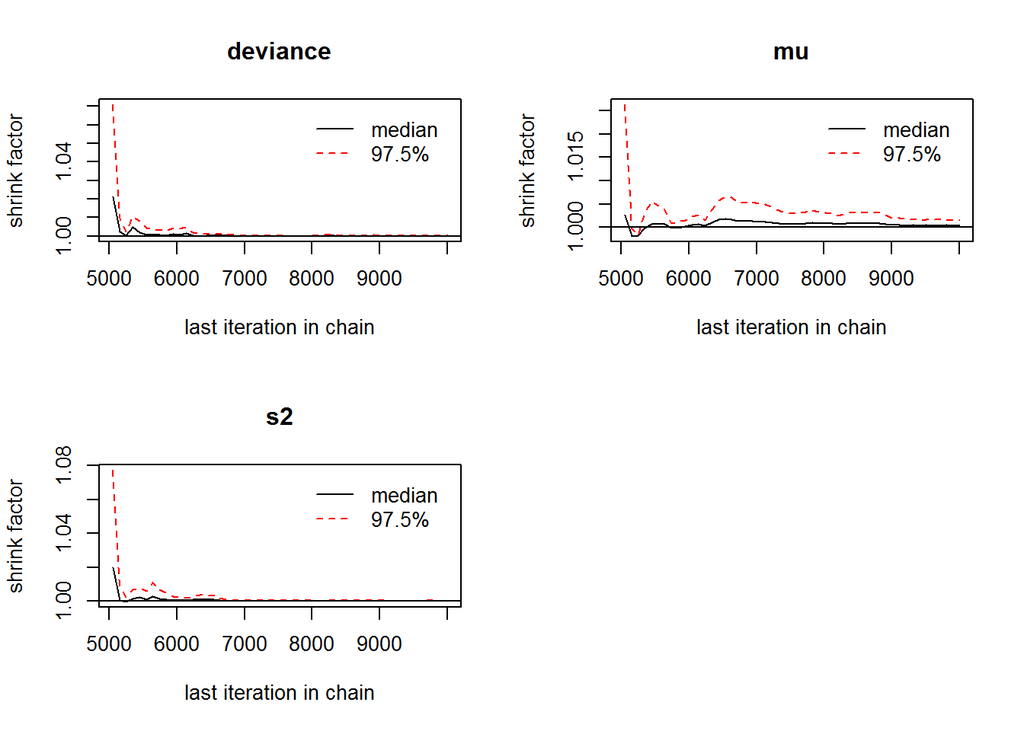

```r
gelman.plot(out.coda)
```

**Click Here to go back to analysis.**

## 4. Informative Prior with one more Hierachical Stage

Here is the R output for Informative Prior with one more Hierachical Stage.

```r
#revise for alpha and beta
model.file=file.path("modelinf10ab.txt")
inits=function(){
  beta<-runif(3,0,50)
  alpha<-20*beta
  tau<-rgamma(3,alpha,beta)
  s.mu<-1/sqrt(tau/3)
  mu<-rnorm(3,4.111,s.mu)
  list(tau,mu,beta)
}
params=c("mu","s2","alpha","beta")
out.hinf=bugs(data,inits,params,model.file,n.chains=3,n.iter = 10000)
print(out.hinf)
```

```
## Inference for Bugs model at "modelinf10ab.txt",
## Current: 3 chains, each with 10000 iterations (first 5000 discarded)
## Cumulative: n.sims = 15000 iterations saved
##          mean    sd 2.5%  25%  50%  75% 97.5% Rhat n.eff
## mu        3.9   0.0  3.8  3.8  3.9  3.9   4.0    1 15000
## s2        0.1   0.0  0.1  0.1  0.1  0.1   0.1    1  4900
## alpha    39.8 121.4  0.7  3.8  8.3 19.1 450.3    1  2000
## beta      2.0   6.1  0.0  0.2  0.4  1.0  22.5    1  2000
## deviance 32.0   4.4 28.2 29.1 30.4 33.1  45.4    1  1800
##
## For each parameter, n.eff is a crude measure of effective sample size,
## and Rhat is the potential scale reduction factor (at convergence, Rhat=1).
##
## DIC info (using the rule, pD = Dbar-Dhat)
## pD = 2.5 and DIC = 34.5
## DIC is an estimate of expected predictive error (lower deviance is better).
```

```r
out.hinf.coda=bugs(data,inits,params,model.file,n.chains=3,n.iter = 10000,codaPkg = T)
out.coda=read.bugs(out.hinf.coda)
```

```
## Abstracting alpha ... 5000 valid values
## Abstracting beta ... 5000 valid values
## Abstracting deviance ... 5000 valid values
## Abstracting mu ... 5000 valid values
## Abstracting s2 ... 5000 valid values
## Abstracting alpha ... 5000 valid values
## Abstracting beta ... 5000 valid values
## Abstracting deviance ... 5000 valid values
## Abstracting mu ... 5000 valid values
## Abstracting s2 ... 5000 valid values
## Abstracting alpha ... 5000 valid values
## Abstracting beta ... 5000 valid values
## Abstracting deviance ... 5000 valid values
## Abstracting mu ... 5000 valid values
## Abstracting s2 ... 5000 valid values
```

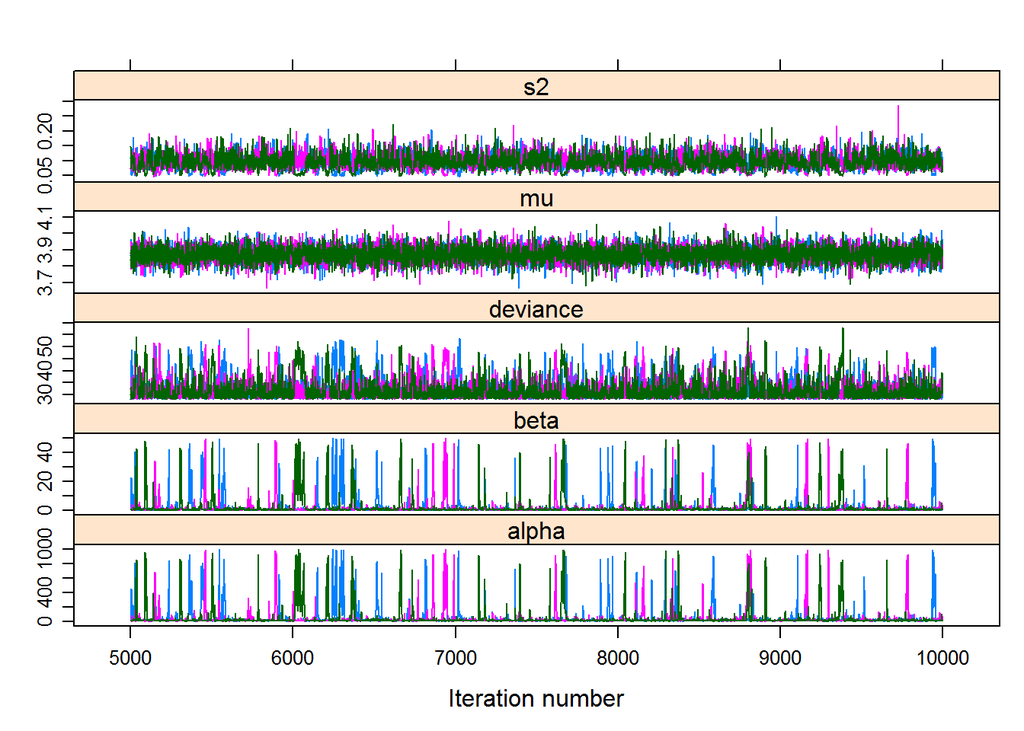

```r
xyplot(out.coda)
```

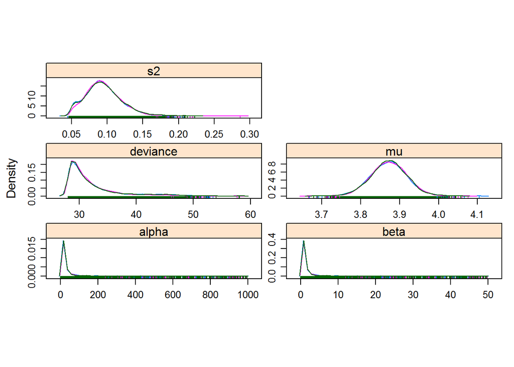

```r
densityplot(out.coda)
```

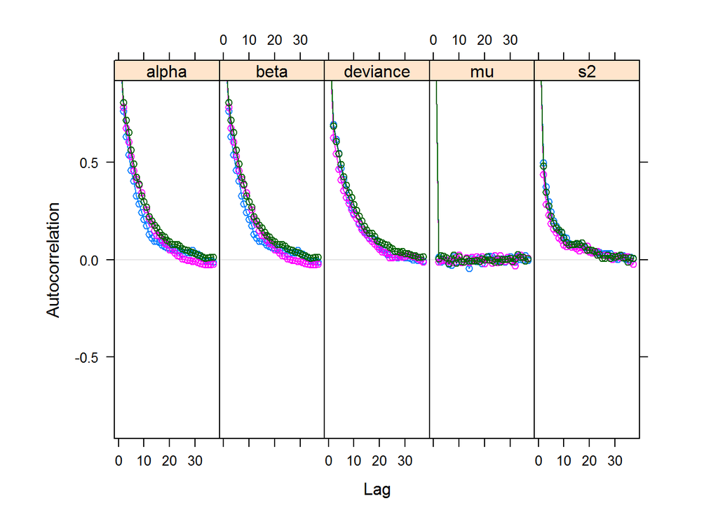

```r
acfplot(out.coda)
```

```r
gelman.diag(out.coda)
```

```
## Potential scale reduction factors:
##
##          Point est. Upper C.I.
## alpha          1.01       1.01
## beta           1.01       1.01
## deviance       1.00       1.01
## mu             1.00       1.00
## s2             1.00       1.00
##
## Multivariate psrf
##
## 1
```

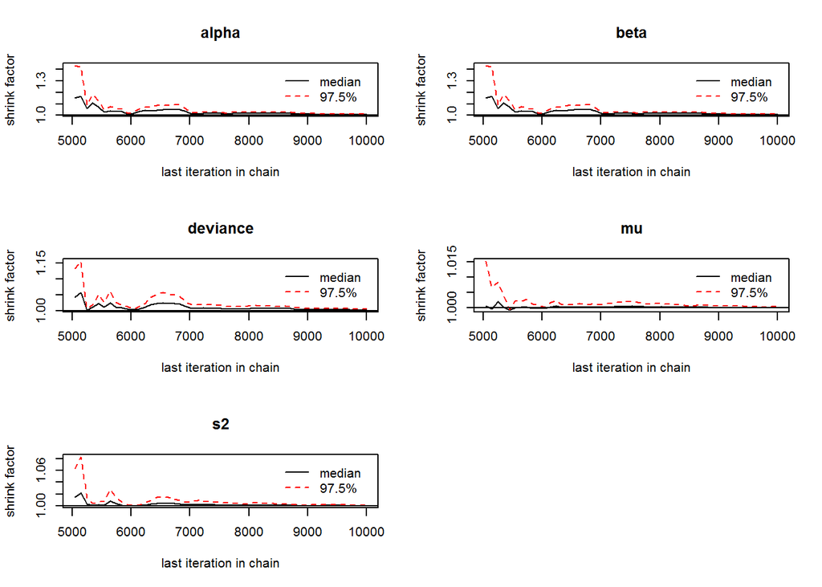

```r
gelman.plot(out.coda)
```

**Click Here to go back to analysis.**